# General Linear Regression Poisson

BH Analytics, LLC

# Objectives

- Review of GLM Framework
- Introduce the Poisson GLM model
- Assess overdispersion
- Introduce the quasi-Poisson model

# General Linear Regression

- We can generalize the ordinary linear model to a more flexible framework
- In regular regression, the predictor variables are on the same scale as the outcome.
- This is often written out in the following form:

$$E(Y) = B_{0} + B_{1}*X_{1} + B_{2}*X_{2} + ... + B_{k}*X_{k} + e$$

- We could also write out this model using the distribution and matrix notation.
- We are assuming the $E(Y)$ follows a normal distribution, with a linear combination of predictors defining the mean, and the variance defined by $sigma$.

$$E(Y) \sim \text{Normal}(\mathbf X \beta,\sigma^2)$$

- A more general framework would be to allow some function to link the predictors to the outcome, and allow different distributions other than the Normal distribution.
- We call this function the ‘link function’.In normal regression it is simply the identity function.
- We can also consider different distributional families for the outcome
- The combination of the link function and the distributional family is the general linear model.

# Poisson Regression

$$log(E(Y | X)) = \beta_0 + \beta_1*X_1 + \beta_2*X_2 + ... + \beta_k*X_k$$

- In Poisson regression, we are modeling a count outcome
- The distributional family we use is the Poisson distribution. This is actually a strict distribution, where the mean is equal to the variance.
- The only parameter is therefore lambda ($\lambda$)
- The link function is simply log
- Predictors are on the log scale here.
- The outcome is discrete positive integers, and zero. So this modeling framework is often used for count outcomes.
  - How many fraud events did a customer have last month?
  - How many sales did an employee make this week?
  - How many insurance claim were made last month under a certain policy?
- We can do some algebraic manipulations to find the expected value of the outcome by taking the exponent of both sides of the equation:

$$E(Y | X) = e^{\beta_0 + \beta_1*X_1 + \beta_2*X_2 + ... + \beta_k*X_k}$$

- And through the laws of exponents, you could rewrite it as the following:

$$E(Y | X) = e^{\beta_0} * e^{\beta_1*X_1} * e^{\beta_2*X_2} * ... e^{\beta_k*X_k}$$

- Thus we consider the Poisson model (and any log linked model) to be a multiplicative model. That is, the predictors we put into the model will be linked to the outcome multiplicatively.

# The Poisson Distribution

Let’s take a moment to further understand the Poisson distribution. We can simulate some data from the Poisson distribution with different means. As we noted above, there is a single parameter, $\lambda$, which is both the mean and the variance. We will start with 1000 realizations from a Poisson distribution with $\lambda = 1$.

```r
set.seed(20)
samp1 = rpois(n=1000,lambda=1)
mean(samp1)
```

```
## [1] 1.031
```

```r
var(samp1)
```

```
## [1] 1.12116
```

As expected, both the mean and the variance are (nearly) equal to 1. We can also view the distribution like so:

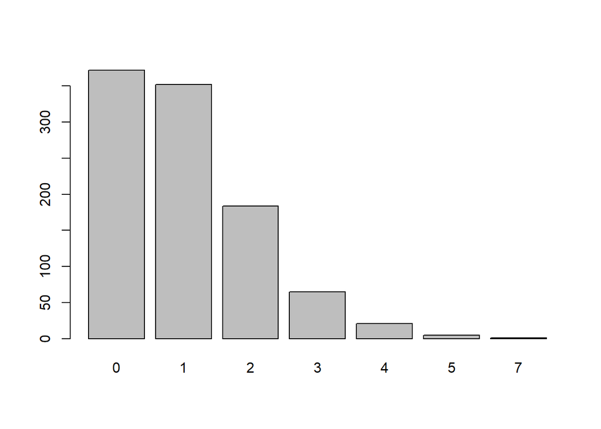

```r
barplot(table(samp1))
```

- What happens if we increase lambda to 10? We should expect a mean and variance equal to 10. Notice how the shape of the distribution changes. Do you think it is reasonable to assume data follows this shape? (More on this later!)

```r
set.seed(20)
samp2 = rpois(n=1000,lambda=10)
mean(samp2)
```

```
## [1] 10.055
```

```r
var(samp2)
```

```
## [1] 10.49447
```

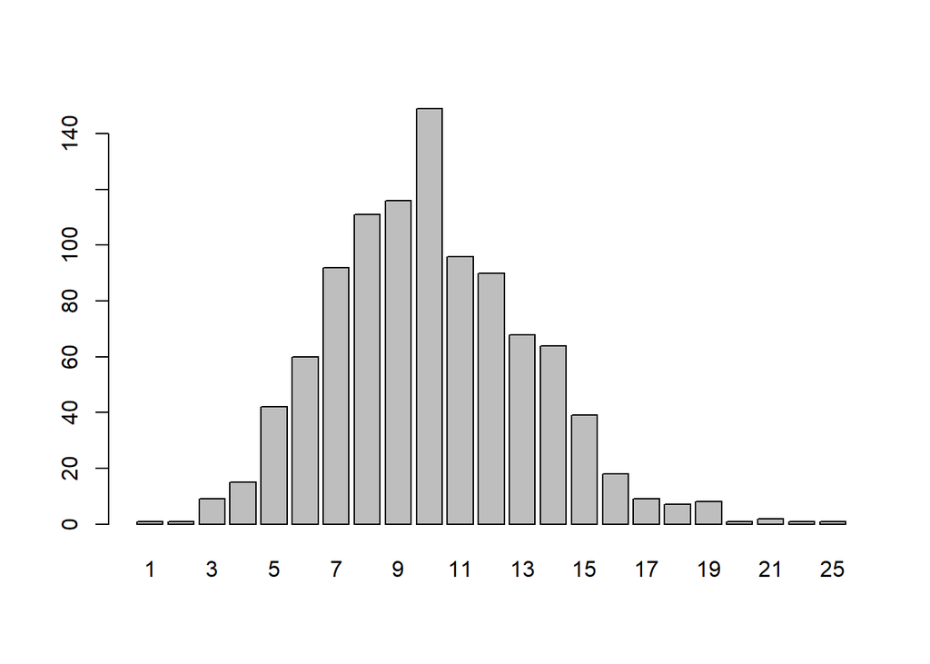

```r
barplot(table(samp2))
```

# Exercise

1. Import the horseshoe crabs data (hcrabs.txt)
2. Set the column names to `c('id','color','spine_condition','wt','carapace_width','satellites)`
3. Examine the data.
4. The outcome is satellites– how many male crabs surround a female crab
5. What’s the mean number of satellites? Median?
6. Produce a histogram of the satellites variable.

```r
library(data.table)
hcrabs <- fread('Data/hcrabs.txt')
setnames(hcrabs,c('id','color','spine_condition','wt','carapace_width','satellites'))
str(hcrabs)
```

```
## Classes 'data.table' and 'data.frame':   173 obs. of  6 variables:
##  $ id             : int  1 2 3 4 5 6 7 8 9 10 ...
##  $ color          : int  2 3 3 4 2 1 4 2 2 2 ...
##  $ spine_condition: int  3 3 3 2 3 2 3 3 1 3 ...
##  $ wt             : num  28.3 26 25.6 21 29 25 26.2 24.9 25.7 27.5 ...
##  $ carapace_width : num  3.05 2.6 2.15 1.85 3 2.3 1.3 2.1 2 3.15 ...
##  $ satellites     : int  8 4 0 0 1 3 0 0 8 6 ...
##  - attr(*, ".internal.selfref")=<externalptr>
```

```r
summary(hcrabs)
```

```
##        id          color       spine_condition       wt       carapace_width    satellites
##  Min.   :  1   Min.   :1.000   Min.   :1.000   Min.   :21.0   Min.   :1.200   Min.   : 0.000
##  1st Qu.: 44   1st Qu.:2.000   1st Qu.:2.000   1st Qu.:24.9   1st Qu.:2.000   1st Qu.: 0.000
##  Median : 87   Median :2.000   Median :3.000   Median :26.1   Median :2.350   Median : 2.000
##  Mean   : 87   Mean   :2.439   Mean   :2.486   Mean   :26.3   Mean   :2.437   Mean   : 2.919
##  3rd Qu.:130   3rd Qu.:3.000   3rd Qu.:3.000   3rd Qu.:27.7   3rd Qu.:2.850   3rd Qu.: 5.000
##  Max.   :173   Max.   :4.000   Max.   :3.000   Max.   :33.5   Max.   :5.200   Max.   :15.000
```

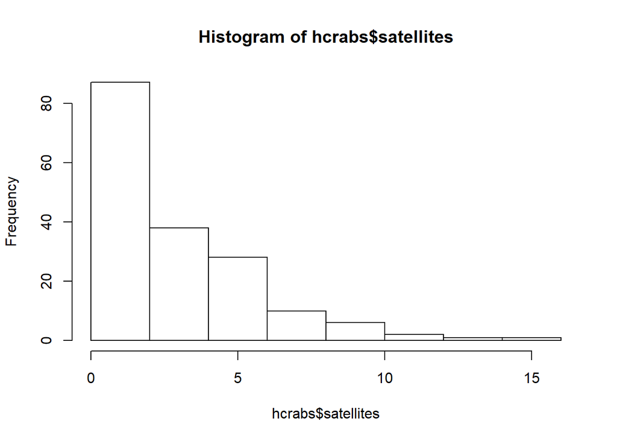

```r
hist(hcrabs$satellites)
```

```r
mean(hcrabs$satellites)
```

```
## [1] 2.919075
```

```r
median(hcrabs$satellites)
```

```
## [1] 2
```

# Fitting Our First Poisson Model

We can use these two distributions to fit our first Poisson models and better understand the link between the estimated model coefficients and the underlying distribution of data. Let’s start with an intercept only model for each sample (null model). Here is the equation we are fitting as a reminder:

$$log(E(Y | X)) = \beta_0$$

We can express this with the mean on the left hand side like so:

$$E(Y | X) = e^{\beta_0}$$

We then fit the model like so:

```r
samp1mod <- glm(samp1 ~ 1,family=poisson)
summary(samp1mod)
```

```
##
## Call:
## glm(formula = samp1 ~ 1, family = poisson)
##
## Deviance Residuals:
##     Min       1Q   Median       3Q      Max
## -1.4360  -1.4360  -0.0307   0.8441   3.8571
##
## Coefficients:
##             Estimate Std. Error z value Pr(>|z|)
## (Intercept)  0.03053    0.03114    0.98    0.327
##
## (Dispersion parameter for poisson family taken to be 1)
##
##     Null deviance: 1216.3  on 999  degrees of freedom
## Residual deviance: 1216.3  on 999  degrees of freedom
## AIC: 2687.5
##
## Number of Fisher Scoring iterations: 5
```

The estimate for the intercept here is 0.03053. Why isn’t it 1? Because the betas are on the log scale! In order to get the mean value of the outcome in this model, we must exponentiate the beta:

$$E(Y | X) = e^{\beta_0}$$

```r
exp(coef(summary(samp1mod))[,'Estimate'])
```

```
## [1] 1.031
```

Let’s fit the other model on the distribution with $\lambda = 10$

```r
samp2mod <- glm(samp2 ~ 1,family=poisson)
summary(samp2mod)
```

```
##
## Call:
## glm(formula = samp2 ~ 1, family = poisson)
##
## Deviance Residuals:
##     Min       1Q   Median       3Q      Max
## -3.6734  -0.6723  -0.0174   0.5950   3.9560
##
## Coefficients:
##             Estimate Std. Error z value Pr(>|z|)
## (Intercept) 2.308070   0.009973   231.4   <2e-16 ***
## ---
## Signif. codes:  0 '***' 0.001 '**' 0.01 '*' 0.05 '.' 0.1 ' ' 1
##
## (Dispersion parameter for poisson family taken to be 1)
##
##     Null deviance: 1052.3  on 999  degrees of freedom
## Residual deviance: 1052.3  on 999  degrees of freedom
## AIC: 5162.6
##
## Number of Fisher Scoring iterations: 4
```

```r
exp(coef(summary(samp2mod))[,'Estimate'])
```

```
## [1] 10.055
```

# Poisson Regression: Doctor’s Visits data

- We will use the Doctor Visits dataset for this exercise
- As always, first inspect your data!
- Also check the help for the data to better understand it.

```r
library(Hmisc)
library(dplyr)
library(AER)
data("DoctorVisits")
?DoctorVisits
## Check data
head(DoctorVisits)
```

```
##   visits gender  age income illness reduced health private freepoor freerepat nchronic lchronic
## 1      1 female 0.19   0.55       1       4      1     yes       no        no       no       no
## 2      1 female 0.19   0.45       1       2      1     yes       no        no       no       no
## 3      1   male 0.19   0.90       3       0      0      no       no        no       no       no
## 4      1   male 0.19   0.15       1       0      0      no       no        no       no       no
## 5      1   male 0.19   0.45       2       5      1      no       no        no      yes       no
## 6      1 female 0.19   0.35       5       1      9      no       no        no      yes       no
```

```r
describe(DoctorVisits)
```

```
## DoctorVisits
##
##  12  Variables      5190  Observations
## --------------------------------------------------------------------------------------------------------------------------------------------------------
## visits
##        n  missing distinct     Info     Mean      Gmd      .05      .10      .25      .50      .75      .90      .95
##     5190        0       10    0.489   0.3017   0.5154        0        0        0        0        0        1        2
##
## lowest : 0 1 2 3 4, highest: 5 6 7 8 9
##
## Value          0     1     2     3     4     5     6     7     8     9
## Frequency   4141   782   174    30    24     9    12    12     5     1
## Proportion 0.798 0.151 0.034 0.006 0.005 0.002 0.002 0.002 0.001 0.000
## --------------------------------------------------------------------------------------------------------------------------------------------------------
## gender
##        n  missing distinct
##     5190        0        2
##
## Value        male female
## Frequency    2488   2702
## Proportion  0.479  0.521
## --------------------------------------------------------------------------------------------------------------------------------------------------------
## age
##        n  missing distinct     Info     Mean      Gmd      .05      .10      .25      .50      .75      .90      .95
##     5190        0       12    0.978   0.4064   0.2258     0.19     0.19     0.22     0.32     0.62     0.72     0.72
##
## lowest : 0.19 0.22 0.27 0.32 0.37, highest: 0.52 0.57 0.62 0.67 0.72
##
## Value       0.19  0.22  0.27  0.32  0.37  0.42  0.47  0.52  0.57  0.62  0.67  0.72
## Frequency    752  1213   523   301   146   126   181   222   273   316   315   822
## Proportion 0.145 0.234 0.101 0.058 0.028 0.024 0.035 0.043 0.053 0.061 0.061 0.158
## --------------------------------------------------------------------------------------------------------------------------------------------------------
## income
##        n  missing distinct     Info     Mean      Gmd      .05      .10      .25      .50      .75      .90      .95
##     5190        0       14    0.983   0.5832   0.4085     0.15     0.25     0.25     0.55     0.90     1.10     1.30
##
## lowest : 0.00 0.01 0.06 0.15 0.25, highest: 0.75 0.90 1.10 1.30 1.50
##
## Value       0.00  0.01  0.06  0.15  0.25  0.35  0.45  0.55  0.65  0.75  0.90  1.10  1.30  1.50
## Frequency     79    35    80   249  1195   462   400   467   455   441   589   361   162   215
```

[output cut: 57 more lines]

```
##        n  missing distinct
##     5190        0        2
##
## Value         no   yes
## Frequency   3098  2092
## Proportion 0.597 0.403
## --------------------------------------------------------------------------------------------------------------------------------------------------------
## lchronic
##        n  missing distinct
##     5190        0        2
##
## Value         no   yes
## Frequency   4585   605
## Proportion 0.883 0.117
## --------------------------------------------------------------------------------------------------------------------------------------------------------
```

# Doctor Visits Data

- There are many possible interesting questions we could ask of this data. For the purpose of focusing this lecture, we seek to answer the following questions:
  - How does private insurance influence the average number of doctors visits in this population?
  - Does this relationship change after we adjust for other covariates?
  - What is the strongest predictor of the number of doctors visits?
- We will start by examining the distribution of the outcome, and fitting a null model (intercept only) as a sanity check.
- Write the code to do the following:
  - Generate a bar plot (or histogram) visually summarizing the distribution of Visits
  - What is the mean and variance of the outcome (visits)?
  - If we use a Poisson model with the intercept only, what do you expect the beta for the intercept to be equal to?

# Doctor Visits Data

- Here are a few ways to implement the following:
  - Generate a bar plot (or histogram) visually summarizing the distribution of Visits
  - What is the mean and variance of the outcome (visits)?
  - If we use a Poisson model with the intercept only, what do you expect the beta for the intercept to be equal to?

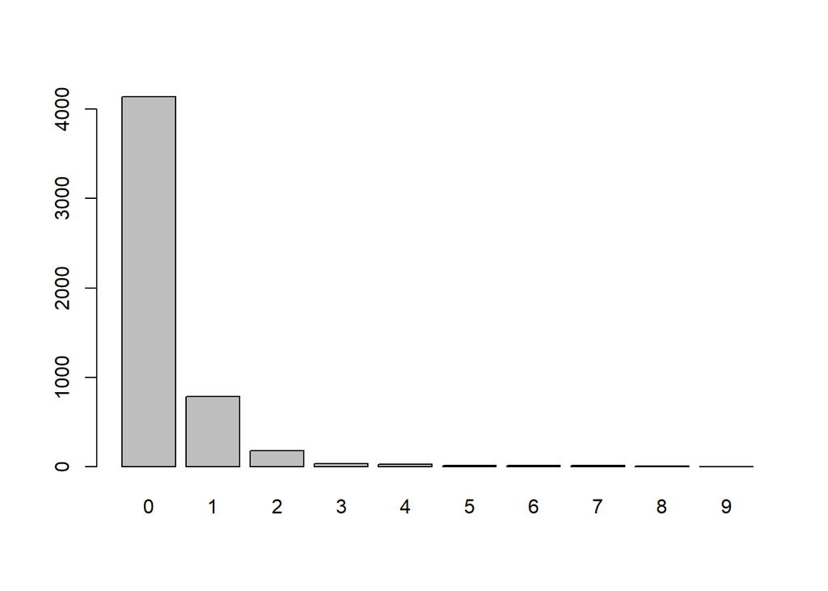

```r
## Create bar plot
barplot(table(DoctorVisits$visits))
```

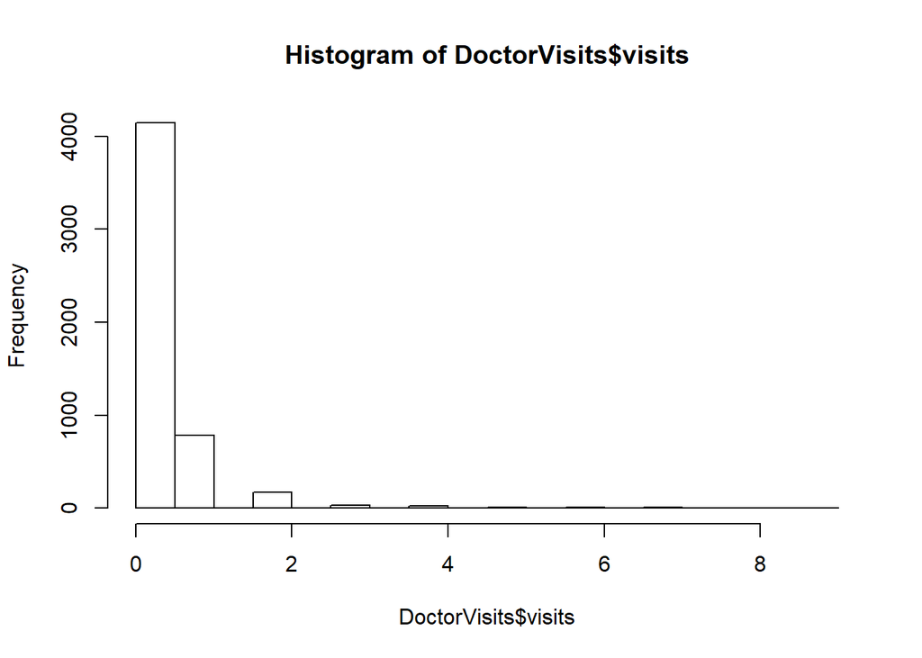

```r
## or histogram
hist(DoctorVisits$visits)
```

```r
## mean
mean(DoctorVisits$visits)
```

```
## [1] 0.3017341
```

```r
## Var
var(DoctorVisits$visits)
```

```
## [1] 0.6370176
```

```r
## Expected beta:
log(mean(DoctorVisits$visits))
```

```
## [1] -1.198209
```

- Recall a key assumption of the Poisson distribution - the mean is equal to the variance. Is that true here?
- Let’s fit the null model now.

# Null Model

- The first Poisson model we might fit is the null model, that is a model with only an intercept.

```r
## Fit Null model
mod1 <- glm(visits ~ 1,
            family=poisson,
            data=DoctorVisits)
summary(mod1)
```

```
##
## Call:
## glm(formula = visits ~ 1, family = poisson, data = DoctorVisits)
##
## Deviance Residuals:
##     Min       1Q   Median       3Q      Max
## -0.7768  -0.7768  -0.7768  -0.7768   6.6122
##
## Coefficients:
##             Estimate Std. Error z value Pr(>|z|)
## (Intercept) -1.19821    0.02527  -47.42   <2e-16 ***
## ---
## Signif. codes:  0 '***' 0.001 '**' 0.01 '*' 0.05 '.' 0.1 ' ' 1
##
## (Dispersion parameter for poisson family taken to be 1)
##
##     Null deviance: 5634.8  on 5189  degrees of freedom
## Residual deviance: 5634.8  on 5189  degrees of freedom
## AIC: 7968.4
##
## Number of Fisher Scoring iterations: 6
```

```r
exp(coef(mod1))
```

```
## (Intercept)
##   0.3017341
```

```r
mean(DoctorVisits$visits)
```

```
## [1] 0.3017341
```

- We can make predictions from this model just like we have done in other glm frameworks. Recall the log linked relationship as you review these results.
- What are we predicting here?
- What is the difference between these two calls below?

```r
## Get predictions
predict(mod1,
        DoctorVisits[1:10,])
```

```
##         1         2         3         4         5         6         7         8         9        10
## -1.198209 -1.198209 -1.198209 -1.198209 -1.198209 -1.198209 -1.198209 -1.198209 -1.198209 -1.198209
```

```r
predict(mod1,
        DoctorVisits[1:10,],type = "response")
```

```
##         1         2         3         4         5         6         7         8         9        10
## 0.3017341 0.3017341 0.3017341 0.3017341 0.3017341 0.3017341 0.3017341 0.3017341 0.3017341 0.3017341
```

# Exercise

1. Recall the mean of the satellites of the horseshoe crab data.
2. Is it equal to the variance?
3. Make a null model of the horseshoe crab data.
4. Backtransform the resulting Intercept. Does it make sense?

# Answer

```r
mean(hcrabs$satellites)
```

```
## [1] 2.919075
```

```r
var(hcrabs$satellites)
```

```
## [1] 9.912018
```

```r
mean(hcrabs$satellites) == var(hcrabs$satellites)
```

```
## [1] FALSE
```

```r
crab0 <- glm(satellites ~ 1,
            family=poisson,
            data=hcrabs)
summary(crab0)
```

```
##
## Call:
## glm(formula = satellites ~ 1, family = poisson, data = hcrabs)
##
## Deviance Residuals:
##     Min       1Q   Median       3Q      Max
## -2.4162  -2.4162  -0.5707   1.1045   4.9942
##
## Coefficients:
##             Estimate Std. Error z value Pr(>|z|)
## (Intercept)   1.0713     0.0445   24.07   <2e-16 ***
## ---
## Signif. codes:  0 '***' 0.001 '**' 0.01 '*' 0.05 '.' 0.1 ' ' 1
##
## (Dispersion parameter for poisson family taken to be 1)
##
##     Null deviance: 632.79  on 172  degrees of freedom
## Residual deviance: 632.79  on 172  degrees of freedom
## AIC: 990.09
##
## Number of Fisher Scoring iterations: 5
```

```r
exp(coef(crab0))
```

```
## (Intercept)
##    2.919075
```

# Adding a Predictor

- Let’s add a single predictor into the model, then make the appropriate interpretation.
- If we add `private` into the model, what does the model look like?

$$log(\overline{\text{visits}}) = \beta_0 + \beta_{\text{private}} * X_\text{private} == 1$$
- What is the mean number of visits for those with and without private insurance?

```r
DoctorVisits %>%
  group_by(private) %>%
  summarise(mean_vis = mean(visits))
```

```
## # A tibble: 2 x 2
##   private mean_vis
##   <fct>      <dbl>
## 1 no         0.307
## 2 yes        0.295
```

- Considering the means calculated above, what do you expect to get for the two beta estimates?
- Let’s fit the model.

```r
## Fit Null model
mod2 <- glm(visits ~ private,
            family=poisson,
            data=DoctorVisits)
summary(mod2)
```

```
##
## Call:
## glm(formula = visits ~ private, family = poisson, data = DoctorVisits)
##
## Deviance Residuals:
##     Min       1Q   Median       3Q      Max
## -0.7841  -0.7841  -0.7676  -0.7676   6.5877
##
## Coefficients:
##             Estimate Std. Error z value Pr(>|z|)
## (Intercept) -1.17961    0.03354 -35.171   <2e-16 ***
## privateyes  -0.04252    0.05101  -0.834    0.405
## ---
## Signif. codes:  0 '***' 0.001 '**' 0.01 '*' 0.05 '.' 0.1 ' ' 1
##
## (Dispersion parameter for poisson family taken to be 1)
##
##     Null deviance: 5634.8  on 5189  degrees of freedom
## Residual deviance: 5634.1  on 5188  degrees of freedom
## AIC: 7969.7
##
## Number of Fisher Scoring iterations: 6
```

```r
exp(coef(mod2))
```

```
## (Intercept)  privateyes
##   0.3073997   0.9583743
```

- Here are the estimates, plugged into the model:

$$log(\overline{\text{visits}}) = -1.17961 + -0.04252 * X_\text{private} == 1$$

$$\overline{\text{visits}} = exp(-1.17961 + -0.04252 * X_\text{private} == 1)$$

$$\overline{\text{visits}} = exp(-1.17961) * exp(-0.04252 * X_\text{private} == 1)$$

- Therefore, the appropriate interpretation of the beta associated with private here is multiplicative.

```r
## The same thing!
exp(-0.04252)
```

```
## [1] 0.9583713
```

```r
DoctorVisits %>%
  group_by(private) %>%
  summarise(mean_vis = mean(visits))
```

```
## # A tibble: 2 x 2
##   private mean_vis
##   <fct>      <dbl>
## 1 no         0.307
## 2 yes        0.295
```

```r
0.2946040/0.3073997
```

```
## [1] 0.9583744
```

- Those with private insurance have 0.958 times the number of visits as those without. Not a large difference!

# Adding more predictors into the model

- Let’s consider a model with a few more covariates.
- How do you interpret these results?
- Can you write down the actual model being fit?

```r
## Fit  model
mod3 <- glm(visits ~ private + gender + age,
            family=poisson,
            data=DoctorVisits)
summary(mod3)
```

```
##
## Call:
## glm(formula = visits ~ private + gender + age, family = poisson,
##     data = DoctorVisits)
##
## Deviance Residuals:
##     Min       1Q   Median       3Q      Max
## -0.9965  -0.8177  -0.6902  -0.6097   6.4763
##
## Coefficients:
##              Estimate Std. Error z value Pr(>|z|)
## (Intercept)  -1.94200    0.06968 -27.872  < 2e-16 ***
## privateyes   -0.01115    0.05133  -0.217    0.828
## genderfemale  0.25902    0.05473   4.732 2.22e-06 ***
## age           1.36492    0.12663  10.779  < 2e-16 ***
## ---
## Signif. codes:  0 '***' 0.001 '**' 0.01 '*' 0.05 '.' 0.1 ' ' 1
##
## (Dispersion parameter for poisson family taken to be 1)
##
##     Null deviance: 5634.8  on 5189  degrees of freedom
## Residual deviance: 5447.2  on 5186  degrees of freedom
## AIC: 7786.8
##
## Number of Fisher Scoring iterations: 6
```

- Model being fit:

$$log(\overline{\text{visits}}) = \beta_0 + \beta_{\text{private}} * X_\text{private} + \beta_{\text{age}} * X_\text{age} + \beta_{\text{female}} * X_\text{female}$$

- Example interpretation:
  - Females have 1.29 times the mean rate of visits compared with males.
  - Can you interpret the rest of these numbers below?

```r
## Gender
exp(coef(summary(mod3))['genderfemale','Estimate'])
```

```
## [1] 1.295666
```

```r
## Age for 10 year increment
exp(coef(summary(mod3))['age','Estimate']*0.1)
```

```
## [1] 1.146246
```

```r
## Private insurance
exp(coef(summary(mod3))['privateyes','Estimate']*0.1)
```

```
## [1] 0.9988856
```

# Exercise

1. Add `carapace_width` as a predictor into the horseshoe crab model.
2. Is it significantly associated with the number of satellites? How do you interpret the result?
3. Create a model of color vs number of satellites. Is female crab color associated with the number of male satellites?
- Is color a quantitative or qualitative variable? Encode it as such.

# Answer

```r
names(hcrabs)
```

```
## [1] "id"              "color"           "spine_condition" "wt"              "carapace_width"  "satellites"
```

```r
crab1 <- glm(satellites ~ carapace_width,
            family=poisson,
            data=hcrabs)
summary(crab1)
```

```
##
## Call:
## glm(formula = satellites ~ carapace_width, family = poisson,
##     data = hcrabs)
##
## Deviance Residuals:
##     Min       1Q   Median       3Q      Max
## -2.9306  -1.9981  -0.5627   0.9299   4.9992
##
## Coefficients:
##                Estimate Std. Error z value Pr(>|z|)
## (Intercept)     -0.4282     0.1789  -2.394   0.0167 *
## carapace_width   0.5892     0.0650   9.065   <2e-16 ***
## ---
## Signif. codes:  0 '***' 0.001 '**' 0.01 '*' 0.05 '.' 0.1 ' ' 1
##
## (Dispersion parameter for poisson family taken to be 1)
##
##     Null deviance: 632.79  on 172  degrees of freedom
## Residual deviance: 560.84  on 171  degrees of freedom
## AIC: 920.14
##
## Number of Fisher Scoring iterations: 5
```

```r
exp(coef(crab1))
```

```
##    (Intercept) carapace_width
##      0.6516963      1.8025307
```

```r
crab2 <- glm(satellites ~ factor(color),
            family=poisson,
            data=hcrabs)
summary(crab2)
```

```
##
## Call:
## glm(formula = satellites ~ factor(color), family = poisson, data = hcrabs)
##
## Deviance Residuals:
##     Min       1Q   Median       3Q      Max
## -2.8577  -2.1106  -0.1649   0.8721   4.7491
##
## Coefficients:
##                Estimate Std. Error z value Pr(>|z|)
## (Intercept)      1.4069     0.1429   9.848  < 2e-16 ***
## factor(color)2  -0.2146     0.1536  -1.397 0.162487
## factor(color)3  -0.6061     0.1750  -3.464 0.000532 ***
## factor(color)4  -0.6913     0.2065  -3.348 0.000814 ***
## ---
## Signif. codes:  0 '***' 0.001 '**' 0.01 '*' 0.05 '.' 0.1 ' ' 1
##
## (Dispersion parameter for poisson family taken to be 1)
##
##     Null deviance: 632.79  on 172  degrees of freedom
## Residual deviance: 609.14  on 169  degrees of freedom
## AIC: 972.44
##
## Number of Fisher Scoring iterations: 6
```

# Predicting from Poisson GLM

- Predictions work the same way as they did before. But…remember that the beta’s are on a different scale than the outcome! So we must decide which predictions scale we want.
- Here are some predictions for a a range of ages, gender, and private insurance.

```r
pred_df <- expand.grid(gender=factor(c('female','male')),
                       age=c(0.2,0.5,0.7),
                       private=factor(c('yes','no')))
pred_df$pred_beta <-
  predict(mod3,newdata=pred_df)
pred_df$pred_lambda <-
  predict(mod3,
          newdata=pred_df,
          type='response')
pred_df
```

```
##    gender age private  pred_beta pred_lambda
## 1  female 0.2     yes -1.4211444   0.2414376
## 2    male 0.2     yes -1.6801689   0.1863425
## 3  female 0.5     yes -1.0116688   0.3636117
## 4    male 0.5     yes -1.2706934   0.2806370
## 5  female 0.7     yes -0.7386852   0.4777417
## 6    male 0.7     yes -0.9977098   0.3687229
## 7  female 0.2      no -1.4099939   0.2441448
## 8    male 0.2      no -1.6690185   0.1884319
## 9  female 0.5      no -1.0005184   0.3676888
## 10   male 0.5      no -1.2595430   0.2837837
## 11 female 0.7      no -0.7275347   0.4830985
## 12   male 0.7      no -0.9865593   0.3728574
```

# Exercise

What is a prediction for the number of satellites expected for a horshoe crab with a wt of 26.3 and color #2?

# Answer

```r
crab3 <- glm(satellites ~ factor(color) + wt,
            family=poisson,
            data=hcrabs)
summary(crab3)
```

```
##
## Call:
## glm(formula = satellites ~ factor(color) + wt, family = poisson,
##     data = hcrabs)
##
## Deviance Residuals:
##     Min       1Q   Median       3Q      Max
## -3.0415  -1.9581  -0.5575   0.9830   4.7523
##
## Coefficients:
##                Estimate Std. Error z value Pr(>|z|)
## (Intercept)    -2.65004    0.58802  -4.507 6.58e-06 ***
## factor(color)2 -0.19969    0.15364  -1.300   0.1937
## factor(color)3 -0.43636    0.17636  -2.474   0.0133 *
## factor(color)4 -0.44736    0.20912  -2.139   0.0324 *
## wt              0.14934    0.02084   7.166 7.73e-13 ***
## ---
## Signif. codes:  0 '***' 0.001 '**' 0.01 '*' 0.05 '.' 0.1 ' ' 1
##
## (Dispersion parameter for poisson family taken to be 1)
##
##     Null deviance: 632.79  on 172  degrees of freedom
## Residual deviance: 559.34  on 168  degrees of freedom
## AIC: 924.64
##
## Number of Fisher Scoring iterations: 6
```

```r
new_data <- data.frame(wt=c(26.3),
                       color=factor(c(2),levels=levels(factor(hcrabs$color))))
new_data
```

```
##     wt color
## 1 26.3     2
```

```r
predict(crab3,
          newdata=new_data,
          type='response')
```

```
##        1
## 2.938755
```